# PART 1- LENDING CLUB

```python
import pandas as pd
import numpy as np
import matplotlib.pyplot as plt
import seaborn as sns
import scipy.stats as stats
import sklearn
from keras import Model
import xgboost as xgb
import shap
import tensorflow as tf
from sklearn.linear_model import Ridge
from sklearn.metrics import mean_squared_error
from sklearn.linear_model import LinearRegression
from sklearn.preprocessing import OneHotEncoder
from sklearn.model_selection import train_test_split
from keras.layers import BatchNormalization, Dropout, Dense
from tensorflow.keras.optimizers import Adam
from sklearn.preprocessing import StandardScaler
from sklearn.neighbors import KNeighborsRegressor


df = pd.read_csv('loans_full_schema.csv')
df.head()
```

|  | emp_title | emp_length | state | homeownership | annual_income | verified_income | debt_to_income | annual_income_joint | verification_income_joint | debt_to_income_joint | ... | sub_grade | issue_month | loan_status | initial_listing_status | disbursement_method | balance | paid_total | paid_principal | paid_interest | paid_late_fees |
| --- | --- | --- | --- | --- | --- | --- | --- | --- | --- | --- | --- | --- | --- | --- | --- | --- | --- | --- | --- | --- | --- |
| 0 | global config engineer | 3.0 | NJ | MORTGAGE | 90000.0 | Verified | 18.01 | NaN | NaN | NaN | ... | C3 | Mar-2018 | Current | whole | Cash | 27015.86 | 1999.33 | 984.14 | 1015.19 | 0.0 |
| 1 | warehouse office clerk | 10.0 | HI | RENT | 40000.0 | Not Verified | 5.04 | NaN | NaN | NaN | ... | C1 | Feb-2018 | Current | whole | Cash | 4651.37 | 499.12 | 348.63 | 150.49 | 0.0 |
| 2 | assembly | 3.0 | WI | RENT | 40000.0 | Source Verified | 21.15 | NaN | NaN | NaN | ... | D1 | Feb-2018 | Current | fractional | Cash | 1824.63 | 281.80 | 175.37 | 106.43 | 0.0 |
| 3 | customer service | 1.0 | PA | RENT | 30000.0 | Not Verified | 10.16 | NaN | NaN | NaN | ... | A3 | Jan-2018 | Current | whole | Cash | 18853.26 | 3312.89 | 2746.74 | 566.15 | 0.0 |
| 4 | security supervisor | 10.0 | CA | RENT | 35000.0 | Verified | 57.96 | 57000.0 | Verified | 37.66 | ... | C3 | Mar-2018 | Current | whole | Cash | 21430.15 | 2324.65 | 1569.85 | 754.80 | 0.0 |

5 rows × 55 columns

## Step 1: Preliminaries

### Understanding the date range in question

For data with a temporal component, it is often useful to either do a temporal train/test split to marginalize for seasonality factors in a model, or to select a model type that can natively capture any temporal trends (e.g. an RNN.) Let's see if any of that is at play:

```python
# Observe the count of each issue month-- Fairly Consistent
print('Monthly Origination Count')
print(df['issue_month'].value_counts(dropna=False))
```

```
Monthly Origination Count
Mar-2018    3617
Jan-2018    3395
Feb-2018    2988
Name: issue_month, dtype: int64
```

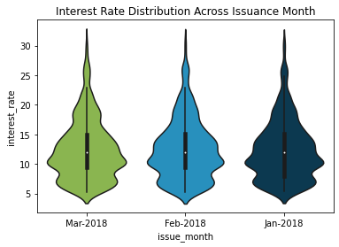

```python
colors = ["#8DC63F", "#0F9AD6", "#013C5B", "#698795", "#000000"]
sns.set_palette(sns.color_palette(colors))

ax = sns.violinplot(x="issue_month",
                    y="interest_rate",
                    data=df).set(title='Interest Rate Distribution Across Issuance Month')
```

### Thoughts on the train/test split

These loans were all originated in Q1 2018 with a fairly even split across Jan/Feb/March. Because this data comes from a relatively small snapshot in time, and because the target distribution seems fairly consistent across each month, I don't think a temporal split or temporally-aware model will be necessary. If there were significant differences between these distributions, we could try training on January's data, validating on February's, and testing on March's to make our model more resilient to temporal effects, but I don't think that will be necessary.

If we had information about the lender or borrower for each loan, I would create a train/test split that ensures the same lender and borrower does not appear in both training and testing sets (to prevent leakage,) but since we do not I'm going to assume these are all unique borrowers and lenders and do a simple random sample for the train/test split.

### Thoughts on the problem & usable features

When conducting research for this problem, I came across this page which seems to give the exact formula LendingClub uses calculating their interest rates: https://www.lendingclub.com/foliofn/rateDetail.action

And indeed, if we transform sub-grade into its numeric equivalent and compare it with interest rate values, we can see that there is a >99% correlation between the two:

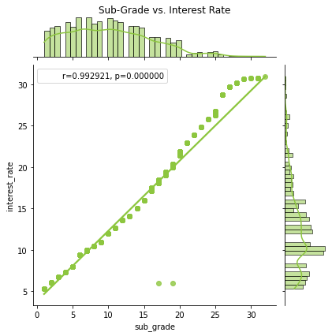

```python
grade_transformation = {
    'A1' : 1, 'A2' : 2, 'A3' : 3, 'A4' : 4, 'A5' : 5,
    'B1' : 6, 'B2' : 7, 'B3' : 8, 'B4' : 9, 'B5' : 10,
    'C1' : 11, 'C2' : 12, 'C3' : 13, 'C4' : 14, 'C5' : 15,
    'D1' : 16, 'D2' : 17, 'D3' : 18, 'D4' : 19, 'D5' : 20,
    'E1' : 21, 'E2' : 22, 'E3' : 23, 'E4' : 24, 'E5' : 25,
    'F1' : 26, 'F2' : 27, 'F3' : 28, 'F4' : 29, 'F5' : 30,
    'G1' : 31, 'G4': 32
}

ax = sns.jointplot(x=df['sub_grade'].map(grade_transformation), y=df['interest_rate'], kind='reg')
r, p = stats.pearsonr(df['sub_grade'].map(grade_transformation), df['interest_rate'])
phantom, = ax.ax_joint.plot([], [], linestyle="", alpha=0)
ax.ax_joint.legend([phantom],['r={:f}, p={:f}'.format(r,p)])
ax.fig.subplots_adjust(top=0.95)
ax.fig.suptitle("Sub-Grade vs. Interest Rate")
plt.show()
```

Just using this and a couple of other features, we can create a nearly perfect model:

```python
df['transformed_subgrade'] = df['sub_grade'].map(grade_transformation)
simple_cols = ['transformed_subgrade', 'annual_income', 'loan_amount', 'term', 'debt_to_income']

X_train, X_test, y_train, y_test = train_test_split(df[simple_cols],
                                                    df['interest_rate'],
                                                    test_size=0.2,
                                                    random_state=43
                                                   )
xgb_mod = xgb.XGBRegressor(colsample_bytree = 0.25,
                           subsample = 0.25,
                           max_depth = 2,
                           n_estimators = 150
                          )
xgb_mod.fit(X_train, y_train)
xgb_preds = xgb_mod.predict(X_test)
xgb_train_score = xgb_mod.score(X_train, y_train)
xgb_test_score = xgb_mod.score(X_test, y_test)
print('XGBoost Train Score: {}'.format(xgb_train_score))
print('XGBoost Test Score: {}'.format(xgb_test_score))
```

```
XGBoost Train Score: 0.9971842311326501
XGBoost Test Score: 0.9980566133802553
```

```
pandas.Int64Index is deprecated and will be removed from pandas in a future version. Use pandas.Index with the appropriate dtype instead.
```

And we can see that these scores are fairly accurate:

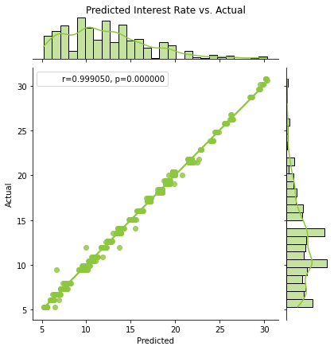

```python
ax = sns.jointplot(x=xgb_preds, y=y_test, kind='reg')
r, p = stats.pearsonr(xgb_preds, y_test)
phantom, = ax.ax_joint.plot([], [], linestyle="", alpha=0)
ax.ax_joint.legend([phantom],['r={:f}, p={:f}'.format(r,p)])
ax.fig.subplots_adjust(top=0.95)
ax.fig.suptitle("Predicted Interest Rate vs. Actual")
ax.set_axis_labels('Predicted', 'Actual', fontsize=10)
plt.show()
```

And I'm sure if we included borrower financials and other deal features, we could potentially push that accuracy even further.

But where's the fun in that?

So for this modeling problem, I'm going to assume that we're trying to predict an interest rate given only

1. A borrower's financials and personal information.
2. The loan amount and term the borrower requested. (More on this shortly)

I'm ignoring certain "deal" features ('installment' (which could be used with the loan amount and term to recover the interest rate,) 'grade', and 'sub_grade') which could leak target information.

I am choosing to include 'loan_amount' and 'term,' because it seems from LendingClub's literature that a borrower sets these in advance of listing their desired loan. Granted, since they are used as modifiers to LendingClub's baseline grade to determine the final interest rate, they may leak some target information. However, they're also so critical in determining an interest rate I want to leave them in for now. At the end of the day the question is what will this model be used for? This work assumes we have the information of what kinds of loan amounts and terms people are looking for and we want to predict the interest rate they might be offered.

One caveat to this logic is that the 'initial_listing_status' feature does seem to indicate that a borrower can dispurse their loan among more than one lender, which perhaps indicates that these "loan amount" and "term" features may not be set in stone, and there may be some interplay between borrowers and lenders haggling over details, but I'm going to set that aside for now and just pretend that the loan amount and term are fixed and can be used in our feature set.

Other assumptions I'm making include:

- The assumption that this is a "pre-origination" model, and as such, any "performace" features in the dataset (these include 'loan_status', 'initial_listing_status', 'disbursement_method', 'balance', 'paid_total', 'paid_principal', 'paid_interest', and 'paid_late_fees') will be ignored.
- The assumption that the credit features present were pulled as of the loan application and not as of latest performance date.
- The assumption that the interest rate is fixed and has not been adjusted since origination.

The last two seem like safe assumptions, but I could not find information in the data dictionary to confirm them.

With our problem now well defined, we can begin modeling!

```python
perf_and_deal_features = ['transformed_subgrade',
       'installment', 'grade', 'sub_grade', 'issue_month',
       'loan_status', 'initial_listing_status', 'disbursement_method',
       'balance', 'paid_total', 'paid_principal', 'paid_interest',
       'paid_late_fees'
]
modeling_df = df.drop(perf_and_deal_features, axis=1)
```

## Step 2: Data Cleaning, EDA, and Feature Engineering

### Handling Columns with Null Values

```python
null_cols = [col for col in modeling_df.columns if sum(modeling_df[col].isnull()) > 0]
for col in null_cols:
    print('{} percent null: {}'.format(col, sum(modeling_df[col].isnull())/modeling_df.shape[0]))
```

```
emp_title percent null: 0.0833
emp_length percent null: 0.0817
debt_to_income percent null: 0.0024
annual_income_joint percent null: 0.8505
verification_income_joint percent null: 0.8545
debt_to_income_joint percent null: 0.8505
months_since_last_delinq percent null: 0.5658
months_since_90d_late percent null: 0.7715
months_since_last_credit_inquiry percent null: 0.1271
num_accounts_120d_past_due percent null: 0.0318
```

How should each of these be handled?

- **emp_title:** Given the context of this feature, I'm going to fill these as strings with the value "NULL." I may not have time to really dive into employment title as much as I might like, so I'm also going to create a dummy variable for missing employment titles, which may be the only feature I derive from this column.
- **emp_length:** This is making an assumption, but if employment title is missing I'm going to assume the individual is unemployed (I was unable to find any listing of "unemployed" or variant thereof in the non-null values of emp_title, and there is a 98% match between null values of "emp_title" and "emp_length".) For these I will fill emp_length as 0, assuming that generally longer employment should be correlated with stability and therefore a potentially lower interest rate.
- **debt_to_income:** because the percentage is so low, I'm going to drop these values. This does beg the question of how to handle missing DTI values if this model were to be deployed, which is a valid concern. If I have time perhaps I can explore some kind of imputation for these missing values.
- **annual_income_joint, verification_income_joint, debt_to_income_joint:** These are tricky because they represent useful information that affects a significant enough segment of the population, but we can't have all of these null values in our model. If we had more credit information about the coborrowers, I would create two separate rows for the borrower and coborrower, and find some calibrated weight between the prediction for the borrower and coborrower that would maximize the model's acccuracy. Given that we only have little information, however, I'm going to treat joint applicants as a single individual and replace their Income, DTI, and Verification with their joint counterparts. There already exists a variable for indicating that indicates whether a loan was joint or not, so I'm not going to include another.
- **months_since_last_delinq, months_since_90d_late, months_since_last_credit_inquiry**: I'm going to assume that these values all represent borrowers who have never had a delinquency, a 90d late, or a previous credit inquiry, and not that this information was simply unavailable (which is a big assumption.) I'm going to make another assumption and say that these features are all, at their core, proxies for recent credit behavior-- e.g., lower values of months_since_last_delinq should be a higher indicator for risk than high values. Because of this, I'm going to fill these values with the maximum of their respective column +1. Tree based models should be able to pick up on this split naturally, but other model types may have a hard time (e.g. linear regressions.) Therefore I will also add a dummy missingness variable for each.
- **num_accounts_120d_past_due**: Because the null percentage is so low, and there is only one non-null unique value (0) for this column, I'm going to drop this feature.

Let's execute that logic:

```python
# emp_title
modeling_df['emp_title_NULL'] = modeling_df['emp_title'].isnull().astype(int)
modeling_df['emp_title'] = modeling_df['emp_title'].apply(lambda x: 'NULL' if pd.isnull(x) else x)

# emp_length
modeling_df['emp_length'] = modeling_df['emp_length'].apply(lambda x: 0 if pd.isnull(x) else x)

# debt_to_income
modeling_df = modeling_df.dropna(subset='debt_to_income')

# annual_income_joint, verification_income_joint, debt_to_income_joint
def convert_income(x):
    if pd.isnull(x['annual_income_joint']):
        return x['annual_income']
    else:
        return x['annual_income_joint']

def convert_verification(x):
    if pd.isnull(x['verification_income_joint']):
        return x['verified_income']
    else:
        return x['verification_income_joint']

def convert_dti(x):
    if pd.isnull(x['debt_to_income_joint']):
        return x['debt_to_income']
    else:
        return x['debt_to_income_joint']

modeling_df['annual_income'] = modeling_df.apply(lambda x: convert_income(x), axis=1)
modeling_df['verified_income'] = modeling_df.apply(lambda x: convert_verification(x), axis=1)
modeling_df['debt_to_income'] = modeling_df.apply(lambda x: convert_dti(x), axis=1)

modeling_df = modeling_df.drop(['annual_income_joint', 'verification_income_joint', 'debt_to_income_joint'], axis=1)

# months_since_last_delinq, months_since_90d_late, months_since_last_credit_inquiry
modeling_df['months_since_last_delinq_NULL'] = modeling_df['months_since_last_delinq'].isnull().astype(int)
modeling_df['months_since_90d_late_NULL'] = modeling_df['months_since_90d_late'].isnull().astype(int)
modeling_df['months_since_last_credit_inquiry_NULL'] = modeling_df['months_since_last_credit_inquiry'].isnull().astype(int)

mmd = max(modeling_df['months_since_last_delinq']) + 1
m90d = max(modeling_df['months_since_90d_late']) + 1
mlc = max(modeling_df['months_since_last_credit_inquiry']) + 1

modeling_df['months_since_last_delinq'] = modeling_df['months_since_last_delinq'].apply(lambda x:
                                                                                        mmd if pd.isnull(x) else x)
modeling_df['months_since_90d_late'] = modeling_df['months_since_90d_late'].apply(lambda x:
                                                                                  m90d if pd.isnull(x) else x)
modeling_df['months_since_last_credit_inquiry'] = modeling_df['months_since_last_credit_inquiry'].apply(lambda x:
                                                                                                        mlc if pd.isnull(x) else x)

# num_accounts_120d_past_due
modeling_df = modeling_df.drop('num_accounts_120d_past_due', axis=1)

# Final Check
for col in modeling_df.columns:
    print('{} percent null: {}'.format(col, sum(modeling_df[col].isnull())/modeling_df.shape[0]))
```

```
emp_title percent null: 0.0
emp_length percent null: 0.0
state percent null: 0.0
homeownership percent null: 0.0
annual_income percent null: 0.0
verified_income percent null: 0.0
debt_to_income percent null: 0.0
delinq_2y percent null: 0.0
months_since_last_delinq percent null: 0.0
earliest_credit_line percent null: 0.0
inquiries_last_12m percent null: 0.0
total_credit_lines percent null: 0.0
open_credit_lines percent null: 0.0
total_credit_limit percent null: 0.0
total_credit_utilized percent null: 0.0
num_collections_last_12m percent null: 0.0
num_historical_failed_to_pay percent null: 0.0
months_since_90d_late percent null: 0.0
current_accounts_delinq percent null: 0.0
total_collection_amount_ever percent null: 0.0
current_installment_accounts percent null: 0.0
accounts_opened_24m percent null: 0.0
months_since_last_credit_inquiry percent null: 0.0
num_satisfactory_accounts percent null: 0.0
num_accounts_30d_past_due percent null: 0.0
num_active_debit_accounts percent null: 0.0
total_debit_limit percent null: 0.0
num_total_cc_accounts percent null: 0.0
num_open_cc_accounts percent null: 0.0
num_cc_carrying_balance percent null: 0.0
num_mort_accounts percent null: 0.0
account_never_delinq_percent percent null: 0.0
tax_liens percent null: 0.0
public_record_bankrupt percent null: 0.0
loan_purpose percent null: 0.0
application_type percent null: 0.0
loan_amount percent null: 0.0
term percent null: 0.0
interest_rate percent null: 0.0
emp_title_NULL percent null: 0.0
months_since_last_delinq_NULL percent null: 0.0
months_since_90d_late_NULL percent null: 0.0
months_since_last_credit_inquiry_NULL percent null: 0.0
```

### Clipping & Transforming Numeric Outliers

I'm hesitant to clip outlier values automatically as much of this data is highly skewed, and relies on infrequent event (e.g. collections.) I'm going to first get a list of numeric and categorical columns, then I will calcullate columns with potential outliers (defined as >5 standard deviations from the mean,) and finally I will do a visual check to confirm which columns I want to clip outliers on and which I want to transform (in this case, log-scale.)

```python
numeric_cols = [col for col in modeling_df.columns if pd.api.types.is_numeric_dtype(modeling_df[col])]
```

```python
cat_cols = list(set(modeling_df.columns) - set(numeric_cols))
```

```
annual_income
Max_value: 2300000.0
```

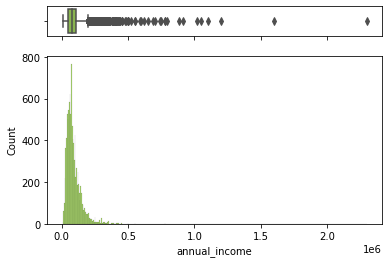

```
delinq_2y
Max_value: 13
```

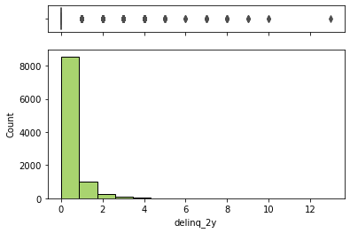

```
inquiries_last_12m
Max_value: 29
```

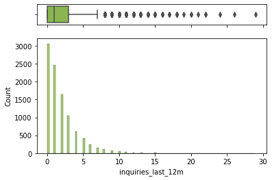

```
total_credit_lines
Max_value: 87
```

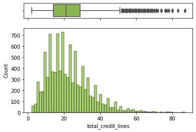

```
open_credit_lines
Max_value: 51
```

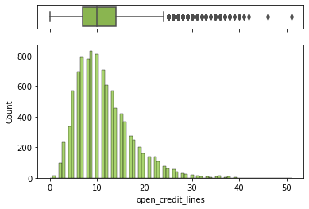

```
total_credit_limit
Max_value: 3386034
```

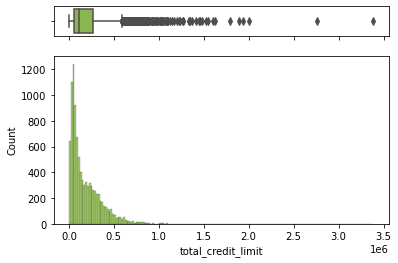

```
total_credit_utilized
Max_value: 942456
```

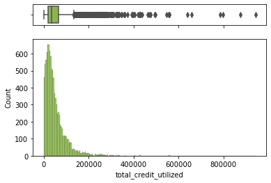

```
num_collections_last_12m
Max_value: 3
```

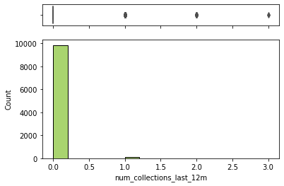

```
num_historical_failed_to_pay
Max_value: 52
```

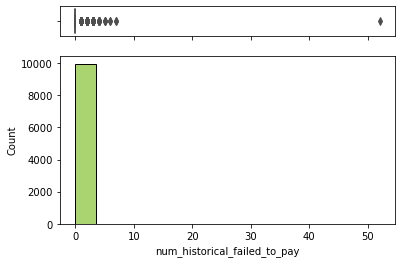

```
current_accounts_delinq
Max_value: 1
```

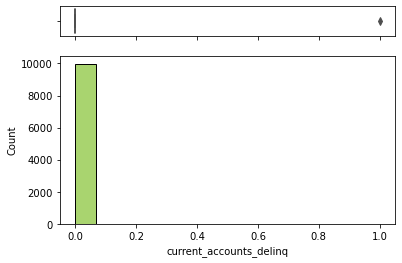

```
total_collection_amount_ever
Max_value: 199308
```

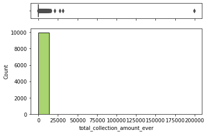

```
current_installment_accounts
Max_value: 35
```

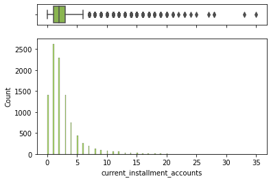

```
accounts_opened_24m
Max_value: 29
```

[11 more figures not shown]

```python
outlier_cols = []
for col in numeric_cols:
    col_limit = np.mean(modeling_df[col]) + 5*np.std(modeling_df[col])
    num_outliers = sum(modeling_df[col]>col_limit)
    if num_outliers > 0:
        outlier_cols.append(col)
for col in outlier_cols:
    print(col)
    print('Max_value: {}'.format(max(modeling_df[col])))
    # creating a figure composed of two matplotlib.Axes objects (ax_box and ax_hist)
    f, (ax_box, ax_hist) = plt.subplots(2, sharex=True, gridspec_kw={"height_ratios": (.15, .85)})

    # assigning a graph to each ax
    sns.boxplot(x=modeling_df[col], ax=ax_box)
    sns.histplot(data=modeling_df, x=col, ax=ax_hist)

    # Remove x axis name for the boxplot
    ax_box.set(xlabel='')
    plt.show()
```

From these plots, the only values I'm very comfortable clipping are annual incomes. This is partially because they are self-reported, while other values come from credit pulls which tend to be more trustworthy, and partially because it's the only column with what seems like a ridiculous skew.

To clip, I will set the annual income as one more than the outlier limit I described above.

I will also create log-transformed versions of the following columns to make them easier to visualize:

- annual_income
- total_credit_limit
- total_credit_utilized
- total_debit_limit

```python
inc_limit = np.mean(modeling_df['annual_income']) + 5*np.std(modeling_df['annual_income'])
modeling_df['annual_income'] = modeling_df['annual_income'].apply(lambda x: inc_limit + 1 if x > inc_limit else x)

# Adding 1 to avoid log(0) issues-- shouldn't change the distributions wildly
modeling_df['log_annual_income'] = np.log(modeling_df['annual_income']+1)
modeling_df['log_total_credit_limit'] = np.log(modeling_df['total_credit_limit']+1)
modeling_df['log_total_credit_utilized'] = np.log(modeling_df['total_credit_utilized']+1)
modeling_df['log_total_debit_limit'] = np.log(modeling_df['total_debit_limit']+1)
```

### EDA- Income Verification

There's so much to explore in this dataset, but one thing that caught my eye is the number of unverified income accounts that this dataset has:

```python
print(modeling_df['verified_income'].value_counts())
```

```
Source Verified    4008
Not Verified       3801
Verified           2167
Name: verified_income, dtype: int64
```

```python
bins_int = [5, 10, 15, 20, 25, 35]
labels_int = ['5-10', '10-15', '15-20','20-25','25+']
modeling_df['Binned_Interest'] = pd.cut(modeling_df['interest_rate'], bins=bins_int, labels=labels_int)

analyse_verification_normed = modeling_df.groupby(['verified_income','Binned_Interest'])['Binned_Interest'].count()
analyse_verification_normed = analyse_verification_normed.groupby(level=0).apply(lambda x: 100 * x / float(x.sum()))
analyse_verification_normed = analyse_verification_normed.unstack()
analyse_verification_normed
```

| Binned_Interest verified_income | 5-10 | 10-15 | 15-20 | 20-25 | 25+ |
| --- | --- | --- | --- | --- | --- |
| Not Verified | 49.750066 | 31.070771 | 14.838200 | 3.051828 | 1.289134 |
| Source Verified | 33.782435 | 37.574850 | 21.756487 | 4.940120 | 1.946108 |
| Verified | 22.842640 | 33.640978 | 28.980157 | 9.644670 | 4.891555 |

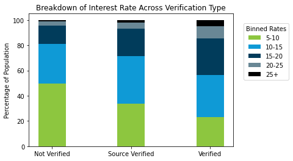

```python
width = 0.35
ft = analyse_verification_normed['5-10']
tef = analyse_verification_normed['10-15']
ftw = analyse_verification_normed['15-20']
twtf = analyse_verification_normed['20-25']
tfp = analyse_verification_normed['25+']

labels = ['Not Verified', 'Source Verified', 'Verified']
fig, ax = plt.subplots()
ax.bar(labels, ft, width,  label='5-10')
ax.bar(labels, tef, width,  bottom=ft, label='10-15')
ax.bar(labels, ftw, width,  bottom=tef+ft, label='15-20')
ax.bar(labels, twtf, width,  bottom=ftw+tef+ft, label='20-25')
ax.bar(labels, tfp, width,  bottom=twtf+ftw+tef+ft, label='25+')

ax.set_ylabel('Percentage of Population')
ax.set_title('Breakdown of Interest Rate Across Verification Type')
ax.legend(loc = [1.05,0.5], title='Binned Rates')

plt.show()
```

That's super interesting! Not at all what I anticipated. I thought for certain that individuals without income verification would recieve higher rates on average, but surprisingly they have the highest proportion of the lowest rates, and the lowest proportion of the highest rates.

I wonder how income and loan amount break down across verification type?

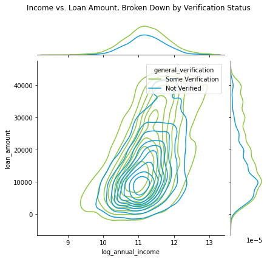

```python
modeling_df['general_verification'] = modeling_df['verified_income'].apply(lambda x: 'Some Verification' if x in ['Verified', 'Source Verified'] else x)
ax = sns.jointplot(data=modeling_df, x="log_annual_income", y="loan_amount", hue="general_verification", kind="kde")
ax.fig.subplots_adjust(top=0.90)
ax.fig.suptitle("Income vs. Loan Amount, Broken Down by Verification Status")
plt.show()
```

Admittedly it's a bit cluttered, but we can see that non-verified borrowers tend to ask for lower amounts, which could account for their lower overall interest rates. Interestingly their income distributions look quite similar.

### Encoding Categorical Features

If I had more time, I would dig into employment title more and try and create some kind of broader categorization for it which captures the "stability," "potential growth," etc. features which employment title may be a proxy for. As we already have a dummy variable for missing employment, I'm going to disregard this feature for now.

Similarly, State is an interesting feature because it can be a proxy for localized economic trends. If I was pulling in external data, matching someone's state to their local unemployment rate, housing price trends, etc. might be interesting. We can capture some of this information by creating ratios of, say, someone's income to their state average (creating an income feature which better normalizes for cost of living fluctuations,) but on it's own I will likely disregard State for now.

The other categorical features ('loan_purpose','application_type', 'homeownership', 'verified_income') I will one-hot encode. For loan purpose, I am bucketing some of the less-frequent values into an "other" category to control the feature space.

```python
cat_cols
```

```
['verified_income',
 'state',
 'emp_title',
 'loan_purpose',
 'application_type',
 'homeownership']
```

```python
loan_purposes_other = [val for val in modeling_df['loan_purpose'].unique() if sum(modeling_df['loan_purpose']==val)<100]
modeling_df['loan_purpose'] = modeling_df['loan_purpose'].apply(lambda x: 'other' if x in loan_purposes_other else x)
modeling_df['loan_purpose'].value_counts()
```

```
debt_consolidation    5132
credit_card           2244
other                 1054
home_improvement       676
major_purchase         303
medical                161
house                  151
car                    131
small_business         124
Name: loan_purpose, dtype: int64
```

```python
to_ohe = ['loan_purpose','application_type', 'homeownership', 'verified_income']

def encode_categoricals(data, categorical):
    enc = OneHotEncoder(drop='if_binary')
    for col in categorical:
        data[col] = data[col].astype(str)
    enc.fit(data[categorical])
    ohe_cols = enc.transform(data[categorical]).toarray()
    feature_names = enc.get_feature_names_out(input_features=categorical)
    ohe_dataset = pd.DataFrame(np.asarray(ohe_cols).reshape((data.shape[0], len(np.asarray(feature_names)))),
                               columns=np.asarray(feature_names),
                               index = data.index)
    non_ohe = list(set(data.columns)-set(categorical))
    data = data[non_ohe].merge(ohe_dataset, left_index=True, right_index=True)
    return data
modeling_df = encode_categoricals(modeling_df, to_ohe)
modeling_df.head().transpose()
```

|  | 0 | 1 | 2 | 3 | 4 |
| --- | --- | --- | --- | --- | --- |
| months_since_last_delinq_NULL | 0 | 1 | 0 | 1 | 1 |
| loan_amount | 28000 | 5000 | 2000 | 21600 | 23000 |
| log_total_credit_limit | 11.167558 | 10.268165 | 10.09386 | 10.142544 | 11.153962 |
| num_satisfactory_accounts | 10 | 14 | 10 | 4 | 16 |
| tax_liens | 0 | 0 | 0 | 1 | 0 |
| ... | ... | ... | ... | ... | ... |
| homeownership_OWN | 0.0 | 0.0 | 0.0 | 0.0 | 0.0 |
| homeownership_RENT | 0.0 | 1.0 | 1.0 | 1.0 | 1.0 |
| verified_income_Not Verified | 0.0 | 1.0 | 0.0 | 1.0 | 0.0 |
| verified_income_Source Verified | 0.0 | 0.0 | 1.0 | 0.0 | 0.0 |
| verified_income_Verified | 1.0 | 0.0 | 0.0 | 0.0 | 1.0 |

61 rows × 5 columns

### Examining Target Correlations to Spot Leakage

Below we observe the full correlation matrix, and zoom in on the interest_rate feature to see if there are any standout variables that might indicate data leakage.

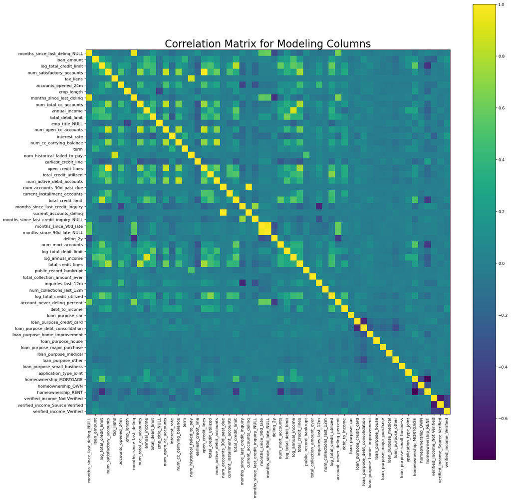

```python
width = 20
corr = modeling_df.corr()
plt.figure(num=None, figsize=(width, width), dpi=80, facecolor='w', edgecolor='k')
corrMat = plt.matshow(corr, fignum = 1)
plt.xticks(range(len(corr.columns)), corr.columns, rotation=90)
plt.yticks(range(len(corr.columns)), corr.columns)
plt.gca().xaxis.tick_bottom()
plt.colorbar(corrMat)
plt.title(f'Correlation Matrix for Modeling Columns', fontsize=25)
plt.show()
```

Double clicking on interest rate, we can see that no features are hugely correlated:

```python
print('Top Correlated Features with Interest Rate: ')
corr['interest_rate'][corr['interest_rate'].abs().sort_values()[::-1][1:11].index.values]
```

```
Top Correlated Features with Interest Rate:
```

```
term                                0.358121
total_debit_limit                  -0.253867
debt_to_income                      0.216962
verified_income_Verified            0.215283
verified_income_Not Verified       -0.209460
log_total_debit_limit              -0.193001
log_total_credit_limit             -0.143472
months_since_last_delinq           -0.140516
num_mort_accounts                  -0.137727
months_since_last_credit_inquiry   -0.134445
Name: interest_rate, dtype: float64
```

Unsurprisingly, term is the most correlated feature with interest rate, which tracks for me. The longer someone's money is at risk, the higher the premium on borrowing it.

Also curious that we again see verification popping up in that unexpected way-- being unverified is negatively correlated with the target, while being verified is positively correlated. I'm curious about the DTI and total debit limit too, let's see the breakdown of both with respect to the target:

```python
binsdti = [1, 10, 20, 30, 40]
labelsdti = ['1-10', '10-20', '20-30','30-40']
modeling_df['Binned_DTI'] = pd.cut(modeling_df['debt_to_income'], bins=binsdti, labels=labelsdti)

binsint = [5, 10, 15, 20, 25, 35]
labelsint = ['5-10', '10-15', '15-20','20-25','25+']
modeling_df['Binned_Interest'] = pd.cut(modeling_df['interest_rate'], bins=binsint, labels=labelsint)

# Using the log-scaled version to get a better visualization
bins_limit = [1, 6, 8, 10, 12, 14]
labels_limit = ['<6', '6-8', '8-10','10-12','12+']
modeling_df['Binned_Log_Limit'] = pd.cut(modeling_df['log_total_debit_limit'], bins=bins_limit, labels=labels_limit)

analyse_dti_normed = modeling_df.groupby(['Binned_DTI','Binned_Interest'])['Binned_Interest'].count()
analyse_dti_normed = analyse_dti_normed.groupby(level=0).apply(lambda x:
                                                 100 * x / float(x.sum()))
analyse_dti_normed = analyse_dti_normed.unstack()

analyse_limit_normed = modeling_df.groupby(['Binned_Log_Limit','Binned_Interest'])['Binned_Interest'].count()
analyse_limit_normed = analyse_limit_normed.groupby(level=0).apply(lambda x:
                                                 100 * x / float(x.sum()))
analyse_limit_normed = analyse_limit_normed.unstack()
```

[figure not shown]

```python
fig, (ax, ax2) = plt.subplots(ncols=2, figsize=(15,5))
analyse_dti_normed.plot.area(ax = ax2)
ax2.set_title('Interest Rate Block vs. DTI')
ax2.set_xlabel('Binned DTI')
ax2.set_ylabel('Percentage of DTI Bin')
analyse_limit_normed.plot.area(ax = ax)
ax.set_title('Interest Rate Block vs. Credit Limit')
ax.set_xlabel('Binned Credit Limit (log-scale)')
ax.set_ylabel('Percentage of Credit Limit Bin')
plt.show()
```

There are definitely some clear trends there, I'm looking forward to modeling with these!

I'm going to manually engineer just a couple more features and then get to modeling! If I had more time, I would generate many new features automatically and try some different feature selection techniques to detect the "gold nuggets," but for now I'm going to just use my intuition to create some that I think will be useful.

```python
# Many models have trouble capturing "ratio" relationships between features,
# so I'm going to create a few of those to see if they're important
modeling_df['ratio_loan_amount_to_income'] = modeling_df['loan_amount'] / modeling_df['annual_income']
modeling_df['ratio_cc_usage'] = modeling_df['num_cc_carrying_balance'] / modeling_df['num_total_cc_accounts']
modeling_df['ratio_active_lines'] = modeling_df['open_credit_lines'] / modeling_df['total_credit_lines']

# Also creating some "normalized" income and loan amount features that place them relative to state averages
# (choosing median for income and loan amount because they're both fairly skewed)
state_income_avgs = modeling_df.groupby('state')['annual_income'].median().to_dict()
state_loan_amount_avgs = modeling_df.groupby('state')['loan_amount'].median().to_dict()

modeling_df['ratio_income_to_state_avg'] = modeling_df.apply(lambda x: x['annual_income']/state_income_avgs[x['state']], axis=1)
modeling_df['ratio_loan_amt_to_state_avg'] = modeling_df.apply(lambda x: x['loan_amount']/state_loan_amount_avgs[x['state']], axis=1)
```

## Step 4: Modeling

I'm going to create three different models: one ridge regression, one tree-based regressor, and one deep network regressor. I'll compare the results of each and unpack their scores.

- First thing is to drop columns I created along the way for visualization, as well as other unusable columns (state, emp_title.)
- Then I will create a train/test split, and some standardized feature sets for training the Linear Regression and Neural Network.
- I will create each model, examine the train and test scores of each, and plot them with a regression line

```python
# Along the way we created some new columns for visualizing data, let's drop those along with transformed columns
# and columns that we deemed unusable for now
cols_to_drop = ['state',
                'log_total_credit_utilized',
                'log_total_debit_limit',
                'log_annual_income',
                'log_total_credit_limit',
                'emp_title',
                'Binned_DTI',
                'Binned_Log_Limit',
                'Binned_Interest',
                'general_verification'
               ]
modeling_df = modeling_df.drop(cols_to_drop, axis=1)
training_data = modeling_df.drop('interest_rate', axis=1)
training_targs = modeling_df['interest_rate']

X_train, X_test, y_train, y_test = train_test_split(training_data,
                                                    training_targs,
                                                    test_size=0.2,
                                                    random_state=43
                                                   )
```

#### Standard Scaling (for Linear Regression and NN)

```python
scaler = StandardScaler()
scaler.fit(X_train)
X_train_scaled = pd.DataFrame(scaler.transform(X_train),
                              columns=X_train.columns,
                              index=X_train.index)
X_test_scaled = pd.DataFrame(scaler.transform(X_test),
                              columns=X_test.columns,
                              index=X_test.index)
```

The first model I wanted to use is an L2 normalized (ridge) regression model:

```python
reg = Ridge(alpha=1).fit(X_train_scaled, y_train)
reg_preds = reg.predict(X_test_scaled)
reg_mse = mean_squared_error(y_test, reg_preds)
print('Linear Regression Train Score: {}'.format(reg.score(X_train_scaled, y_train)))
print('Linear Regression Test Score: {}'.format(reg.score(X_test_scaled, y_test)))
print("Linear Regression Test Score (MSE): {}".format(reg_mse))
print("Linear Regression Test Score (RMSE): {}".format(reg_mse**(1/2.0)))
```

```
Linear Regression Train Score: 0.39075772111606555
Linear Regression Test Score: 0.41145971077284926
Linear Regression Test Score (MSE): 14.939375421739587
Linear Regression Test Score (RMSE): 3.865148822715574
```

```
Pass the following variables as keyword args: x, y. From version 0.12, the only valid positional argument will be `data`, and passing other arguments without an explicit keyword will result in an error or misinterpretation.
```

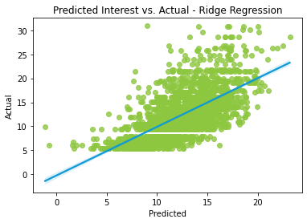

```python
sns.regplot(reg_preds, y_test, scatter_kws={'color': '#8DC63F'}, line_kws={'color': '#0F9AD6'})
plt.xlabel('Predicted')
plt.ylabel('Actual')
plt.title('Predicted Interest vs. Actual - Ridge Regression')
plt.show()
```

As we can see, this is a much harder modeling problem without LendingClub's internal credit score. We are able to show some correlation between our model scores and the actual sccores, but it's nowhere near as strong as our sub-grade model.

The next model I tried was an XGBoost Regressor. To prevent overfitting I used a relatively small number of trees, I aggressively subsampled the column space and row space for each tree, and I used a somewhat high minimum child weight to keep it generalizable:

```python
import xgboost as xgb
xgb_mod = xgb.XGBRegressor(colsample_bytree = 0.25,
                           subsample = 0.25,
                           max_depth = 3,
                           min_child_weight = 10,
                           n_estimators = 30
                          )
xgb_mod.fit(X_train, y_train)
xgb_preds = xgb_mod.predict(X_test)
xgb_train_score = xgb_mod.score(X_train, y_train)
xgb_test_score = xgb_mod.score(X_test, y_test)
xgb_mse = mean_squared_error(y_test, xgb_preds)
print('XGBoost Train Score (R-sqaured): {}'.format(xgb_train_score))
print('XGBoost Test Score (R-sqaured): {}'.format(xgb_test_score))
print("XGBoost Test Score (MSE): {}".format(xgb_mse))
print("XGBoost Test Score (RMSE): {}".format(xgb_mse**(1/2.0)))
```

```
XGBoost Train Score (R-sqaured): 0.41894777765900215
XGBoost Test Score (R-sqaured): 0.3901517473253111
XGBoost Test Score (MSE): 15.48025201293013
XGBoost Test Score (RMSE): 3.9344951407938136
```

```
pandas.Int64Index is deprecated and will be removed from pandas in a future version. Use pandas.Index with the appropriate dtype instead.
```

```
Pass the following variables as keyword args: x, y. From version 0.12, the only valid positional argument will be `data`, and passing other arguments without an explicit keyword will result in an error or misinterpretation.
```

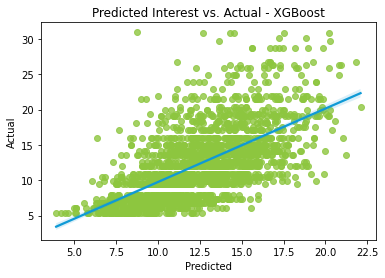

```python
sns.regplot(xgb_preds, y_test, scatter_kws={'color': '#8DC63F'}, line_kws={'color': '#0F9AD6'})
plt.xlabel('Predicted')
plt.ylabel('Actual')
plt.title('Predicted Interest vs. Actual - XGBoost')
plt.show()
```

Finally, I created a shallow neural network to see if I could boost the score any further:

```python
def nn_model(num_columns, num_labels, hidden_units, dropout_rates, learning_rate):
    inp = tf.keras.layers.Input(shape=(num_columns, ))
    x = BatchNormalization()(inp)
    x = Dropout(dropout_rates[0])(x)
    for i in range(len(hidden_units)):
        x = Dense(hidden_units[i], activation='relu')(x)
        x = BatchNormalization()(x)
        x = Dropout(dropout_rates[i + 1])(x)
    x = Dense(num_labels)(x)

    model = Model(inputs=inp, outputs=x)
    model.compile(optimizer=Adam(learning_rate),
                  loss='mean_absolute_error',
                  metrics=[tf.keras.metrics.MeanSquaredError()]
                 )
    return model

num_columns = X_train_scaled.shape[1]
num_labels = 1
hidden_units = [16]
dropout_rates = [0.1, 0, 0.1, 0]
learning_rate = 1e-3

dn_mod = nn_model(
    num_columns=num_columns,
    num_labels=num_labels,
    hidden_units=hidden_units,
    dropout_rates=dropout_rates,
    learning_rate=learning_rate
)

r = dn_mod.fit(
    X_train_scaled, y_train,
    validation_data=(X_test_scaled, y_test),
    epochs=100,
    batch_size=256,
    verbose = False
)

dn_preds_train = dn_mod.predict(X_train_scaled)
dn_preds = dn_mod.predict(X_test_scaled)
dn_mse = mean_squared_error(y_test, dn_preds)

def R_squared(y, y_pred):
    residual = sum((y - y_pred)**2)
    total_ss = sum((y - np.mean(y))**2)
    r2 = 1-residual/total_ss
    return r2

print('Neural Net Train Score: {}'.format(R_squared(y_train, dn_preds_train.flatten())))
print('Neural Net Test Score: {}'.format(R_squared(y_test, dn_preds.flatten())))
print("Neural Net Test Score (MSE): {}".format(dn_mse))
print("Neural Net Test Score (RMSE): {}".format(dn_mse**(1/2.0)))
```

```
Neural Net Train Score: 0.4219667911195908
Neural Net Test Score: 0.4044375329167389
Neural Net Test Score (MSE): 15.117624818069604
Neural Net Test Score (RMSE): 3.888138991608917
```

```
Pass the following variables as keyword args: x, y. From version 0.12, the only valid positional argument will be `data`, and passing other arguments without an explicit keyword will result in an error or misinterpretation.
```

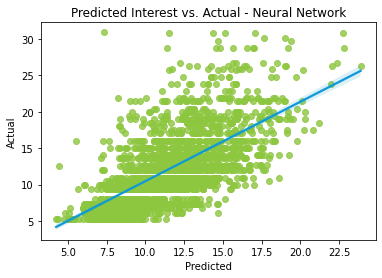

```python
sns.regplot(dn_preds, y_test, scatter_kws={'color': '#8DC63F'}, line_kws={'color': '#0F9AD6'})
plt.xlabel('Predicted')
plt.ylabel('Actual')
plt.title('Predicted Interest vs. Actual - Neural Network')
plt.show()
```

One final model I considered was a K Nearest Neighbors model. Below I've plotted the resulting r-sqaured value on the train and test sets as a function of the number of neighbors. As we can see, they converge at an r-squared of ~0.3, so I elected not to continue developing this model.

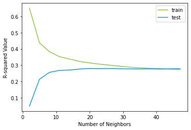

```python
neighbors = np.arange(2, 50, 3)
tr_rsq = []
te_rsq = []
for n in neighbors:
    knn = KNeighborsRegressor(n_neighbors=n).fit(X_train_scaled, y_train)
    knn_preds_train = knn.predict(X_train_scaled)
    knn_preds = knn.predict(X_test_scaled)
    tr_rsq.append(R_squared(y_train, knn_preds_train))
    te_rsq.append(R_squared(y_test, knn_preds))

plt.figure()
plt.plot(neighbors, tr_rsq)
plt.plot(neighbors, te_rsq)
plt.xlabel('Number of Neighbors')
plt.ylabel('R-squared Value')
plt.legend(['train', 'test'])
```

## Step 5: Model Decomposition

One interesting thing I love to double click into is model decomposition. I unfortunately don't have the time for an exhaustive deep dive, but I wanted to give a flavor of what it can tell you about how you model treats your features.

Shown below are two kinds of explainability: SHAP values (applied to the ridge regression and XGB models) and Integrated Gradients (applied to the neurall network.) Each plot shows the top 20 most important features in the model; the color indicates how high or low the feature value is, and the position of each data point shows how it influences the model's score (right meaning a higher interest rate, left meaning a lower interest rate.)

For example, we can see below that the loan term is the most important feature in the ridge model. When its value is high it indicates a higher interest rate, and when its value is low it indicates a lower interest rate. We can see that toal debit limit is also an important feature, but its behavior is opposite: when the feature values are low, it's a semi-weak indicator towards a higher interest rate, but when the values are high it's a strong indicator towards a lower interest rate.

```
SHAP Values for the Ridge Regressor:
```

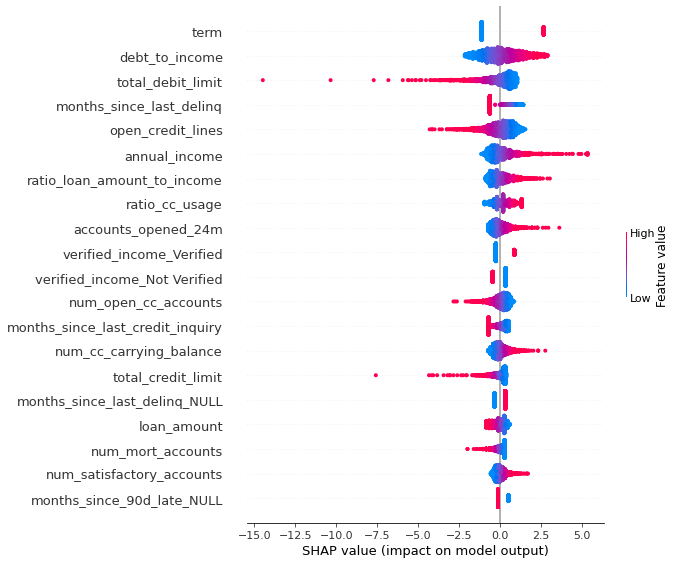

```python
print('SHAP Values for the Ridge Regressor: ')
masker = shap.maskers.Independent(data = X_train_scaled)
reg_explainer = shap.LinearExplainer(reg, masker)
shap_values_reg = reg_explainer.shap_values(X_test_scaled)
plt.figure()
shap.summary_plot(shap_values_reg, X_test_scaled)
```

```
SHAP Values for the XGBoost Model:
```

```
pandas.Int64Index is deprecated and will be removed from pandas in a future version. Use pandas.Index with the appropriate dtype instead.
ntree_limit is deprecated, use `iteration_range` or model slicing instead.
```

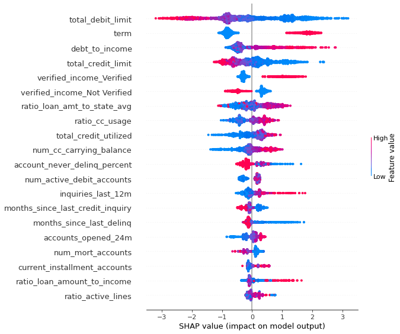

```python
# Shap
print('SHAP Values for the XGBoost Model: ')
tree_explainer = shap.TreeExplainer(xgb_mod)
shap_values_tree = tree_explainer.shap_values(X_test)
plt.figure()
shap.summary_plot(shap_values_tree, X_test)
```

```python
def tf_integrated_gradients(ob, base, model, n_steps):

    assert len(model.input.shape) == len(ob.shape), \
                                    "Model input and passed observation should have same length shape"
    def _parameterize(ob, base, n_steps):
        """
        See above docstring for arg defs
        """
        step = tf.math.divide(tf.math.subtract(ob, base), n_steps)
        path = []
        for i in range(n_steps):
            path.append(base+(step*i))
        return path, step

    if len(base.shape) != len(ob.shape):
        assert False, "reference should have the same shape as the observation. Try using np.expand_dims(reference, axis=0) if passing one reference point"

    num_refs = base.shape[0]
    all_exps = np.zeros(np.append(num_refs, ob.shape))
    for i in range(base.shape[0]):
        # create path from baseline to observation-- see _paramaterize helper function
        path, step = _parameterize(ob, base[i], n_steps)

        # Item assignment should be coming, look into it
        # https://stackoverflow.com/questions/37697747/typeerror-tensor-object-does-not-support-item-assignment-in-tensorflow
        gradients = []

        # Calculate the gradient w.r.t. the input of the model's prediction for every point in the path
        for step_point in path:

            with tf.GradientTape() as tape:

                # Whatever we watch here, we can get the gradient w.r.t.
                tape.watch(step_point)

                # Get model prediction at our step point
                prediction = model(step_point)

            # Get the gradients of the prediction w.r.t to the input image, assign to gradients[step_i]
            # Also doing an extra step here where we multiply the gradient by the step-- need to for
            # the Riemann sum
            gradients.append(tape.gradient(prediction, step_point)*step)

        # Convert the list of tensors to a single tensor
        gradients = tf.convert_to_tensor(gradients)

        # Sum gradient*step across path
        explanation = tf.reduce_sum(gradients, axis=0)
        all_exps[i] = np.expand_dims(np.array(explanation), axis=0)

    avg_expl = np.mean(all_exps, axis=0)

    return np.array(explanation)
reference_ind = np.where(y_test==np.median(y_test))[0][:1]
ig_vals = tf_integrated_gradients(X_test_scaled.values, X_test_scaled.iloc[reference_ind].values, dn_mod, n_steps=200)
```

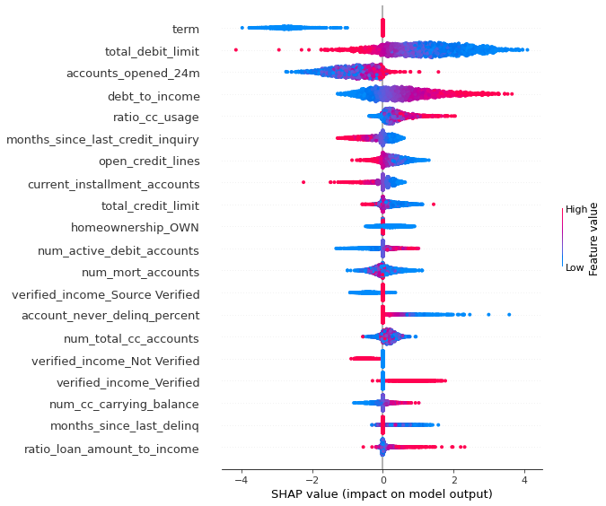

```python
plt.figure()
shap.summary_plot(ig_vals, X_test_scaled)
```

## Conclusion

This was a fun challenge! As we can see, the modeling problem is a lot harder when we don't have access to the internal credit rating of LendingClub, but I was able to show a semi-strong correlation between my model's scores and the actual interest rates. Knowing that we're essentially trying to create a proxy model for LendingClub's grading system, I feel like it might be possible to do a lot better. I believe their scoring system is based on a combination of FICO and their internal credit model, and although we don't have access to FICO we do have a fair bit of bureau data to draw from.

If I had more time in this challenge, I would have done a lot more feature engineering, perhaps incorporating some automated feature creation and selection, I would have spent longer hypertuning my models, I would have tried some dimmensionality reduction techniques like PCA to better analyze and model the data, and I would have taken more advantage of the model explainability tools above to better unpack and retool my models.

If you read this far, thank you! This was one of the most fun assessments I've had this year.